# Example: dense logistic regression table

birthwt data with binary, continuous, and polytomous predictors

GRAPH Courses (composer_k8m3)

2026-07-30

# Purpose

This script shows how to build a **single display** that combines:

- raw counts and outcome percentages (with in-cell bars),
- univariable odds ratios,
- multivariable odds ratios,
- forest-style OR plots for **categorical** predictors, and
- a continuous OR **curve** (with CI ribbon) for continuous predictors, while still showing binned raw percentages.

It is meant as a teaching / LLM-prompting reference for the Week 11 challenge. The data are from MASS::`birthwt` ([docs](https://www.rdocumentation.org/packages/MASS/versions/7.3-66/topics/birthwt)).

Predictors:

- `age` (continuous; also shown in age bands for raw %)
- `lwt` (continuous mother weight in pounds; also banded for raw %)
- `race` (polytomous: white / black / other)
- `smoke` (binary)
- `ptl_cat` (polytomous: 0, 1, 2+ previous premature labours)

# Packages and data prep

```r
if (!require(pacman)) install.packages("pacman")
pacman::p_load(tidyverse, broom, patchwork, scales)
# birthwt lives in MASS; load the dataset without attaching MASS
# (MASS::select would mask dplyr::select)
data(birthwt, package = "MASS")
```

```r
bwt <- birthwt %>%
  as_tibble() %>%
  mutate(
    low = factor(low, levels = c(0, 1), labels = c("Normal", "Low")),
    race = factor(race, levels = c(1, 2, 3), labels = c("White", "Black", "Other")),
    smoke = factor(smoke, levels = c(0, 1), labels = c("No", "Yes")),
    ptl_cat = factor(
      case_when(ptl == 0 ~ "0", ptl == 1 ~ "1", TRUE ~ "2+"),
      levels = c("0", "1", "2+")
    ),
    age_band = cut(age, breaks = c(14, 19, 24, 29, 34, Inf),
                   labels = c("14-19", "20-24", "25-29", "30-34", "35+"),
                   include.lowest = TRUE),
    lwt_band = cut(lwt, breaks = c(80, 100, 120, 140, 160, Inf),
                   labels = c("80-100", "101-120", "121-140", "141-160", "161+"),
                   include.lowest = TRUE)
  )

glimpse(bwt)
```

```
## Rows: 189
## Columns: 13
## $ low      <fct> Normal, Normal, Normal, Normal, Normal, Normal, Normal, Norma…
## $ age      <int> 19, 33, 20, 21, 18, 21, 22, 17, 29, 26, 19, 19, 22, 30, 18, 1…
## $ lwt      <int> 182, 155, 105, 108, 107, 124, 118, 103, 123, 113, 95, 150, 95…
## $ race     <fct> Black, Other, White, White, White, Other, White, Other, White…
## $ smoke    <fct> No, No, Yes, Yes, Yes, No, No, No, Yes, Yes, No, No, No, No, …
## $ ptl      <int> 0, 0, 0, 0, 0, 0, 0, 0, 0, 0, 0, 0, 0, 1, 0, 0, 0, 0, 0, 0, 0…
## $ ht       <int> 0, 0, 0, 0, 0, 0, 0, 0, 0, 0, 0, 0, 1, 0, 0, 0, 0, 0, 0, 0, 0…
## $ ui       <int> 1, 0, 0, 1, 1, 0, 0, 0, 0, 0, 0, 0, 0, 1, 0, 0, 0, 0, 1, 0, 0…
## $ ftv      <int> 0, 3, 1, 2, 0, 0, 1, 1, 1, 0, 0, 1, 0, 2, 0, 0, 0, 3, 0, 1, 2…
## $ bwt      <int> 2523, 2551, 2557, 2594, 2600, 2622, 2637, 2637, 2663, 2665, 2…
## $ ptl_cat  <fct> 0, 0, 0, 0, 0, 0, 0, 0, 0, 0, 0, 0, 0, 1, 0, 0, 0, 0, 0, 0, 0…
## $ age_band <fct> 14-19, 30-34, 20-24, 20-24, 14-19, 20-24, 20-24, 14-19, 25-29…
## $ lwt_band <fct> 161+, 141-160, 101-120, 101-120, 101-120, 121-140, 101-120, 1…
```

```r
bwt %>% count(low) %>% mutate(pct = n / sum(n))
```

```
## # A tibble: 2 × 3
##   low        n   pct
##   <fct>  <int> <dbl>
## 1 Normal   130 0.688
## 2 Low       59 0.312
```

# Fit models

```r
# Univariable
uni_age   <- glm(low ~ age, family = binomial, data = bwt)
uni_lwt   <- glm(low ~ lwt, family = binomial, data = bwt)
uni_race  <- glm(low ~ race, family = binomial, data = bwt)
uni_smoke <- glm(low ~ smoke, family = binomial, data = bwt)
uni_ptl   <- glm(low ~ ptl_cat, family = binomial, data = bwt)

# Multivariable
multi <- glm(low ~ age + lwt + race + smoke + ptl_cat, family = binomial, data = bwt)

tidy(multi, conf.int = TRUE, exponentiate = TRUE)
```

```
## # A tibble: 8 × 7
##   term        estimate std.error statistic p.value conf.low conf.high
##   <chr>          <dbl>     <dbl>     <dbl>   <dbl>    <dbl>     <dbl>
## 1 (Intercept)    1.99    1.18       0.585  0.558      0.209     21.5
## 2 age            0.953   0.0375    -1.29   0.197      0.883      1.02
## 3 lwt            0.989   0.00671   -1.71   0.0877     0.975      1.00
## 4 raceBlack      3.01    0.535      2.06   0.0393     1.06       8.75
## 5 raceOther      2.25    0.436      1.86   0.0636     0.965      5.39
## 6 smokeYes       2.39    0.401      2.17   0.0297     1.10       5.36
## 7 ptl_cat1       5.30    0.510      3.27   0.00107    2.01      15.1
## 8 ptl_cat2+      1.09    0.920      0.0943 0.925      0.140      6.24
```

# Helper: raw proportion rows

```r
raw_rows <- function(data, group_var, predictor_label) {
  data %>%
    group_by({{ group_var }}) %>%
    summarise(
      n = n(),
      n_low = sum(low == "Low"),
      pct = mean(low == "Low"),
      .groups = "drop"
    ) %>%
    mutate(
      predictor = predictor_label,
      level = as.character({{ group_var }}),
      row_type = "category"
    ) %>%
    select(predictor, level, n, n_low, pct, row_type)
}

raw_table <- bind_rows(
  raw_rows(bwt, age_band, "Age (years), continuous"),
  raw_rows(bwt, lwt_band, "Mother weight (lb), continuous"),
  raw_rows(bwt, race, "Race"),
  raw_rows(bwt, smoke, "Smoked during pregnancy"),
  raw_rows(bwt, ptl_cat, "Previous premature labours")
)

raw_table
```

```
## # A tibble: 18 × 6
##    predictor                      level       n n_low   pct row_type
##    <chr>                          <chr>   <int> <int> <dbl> <chr>
##  1 Age (years), continuous        14-19      51    15 0.294 category
##  2 Age (years), continuous        20-24      69    25 0.362 category
##  3 Age (years), continuous        25-29      42    15 0.357 category
##  4 Age (years), continuous        30-34      22     4 0.182 category
##  5 Age (years), continuous        35+         5     0 0     category
##  6 Mother weight (lb), continuous 80-100     24    11 0.458 category
##  7 Mother weight (lb), continuous 101-120    68    23 0.338 category
##  8 Mother weight (lb), continuous 121-140    50    13 0.26  category
##  9 Mother weight (lb), continuous 141-160    21     7 0.333 category
## 10 Mother weight (lb), continuous 161+       26     5 0.192 category
## 11 Race                           White      96    23 0.240 category
## 12 Race                           Black      26    11 0.423 category
## 13 Race                           Other      67    25 0.373 category
## 14 Smoked during pregnancy        No        115    29 0.252 category
## 15 Smoked during pregnancy        Yes        74    30 0.405 category
## 16 Previous premature labours     0         159    41 0.258 category
## 17 Previous premature labours     1          24    16 0.667 category
## 18 Previous premature labours     2+          6     2 0.333 category
```

# Helper: OR curve for a continuous predictor

For a continuous coefficient $\beta$, the odds ratio comparing age $x$ to a reference age $x_0$ is $\exp(\beta (x - x_0))$. We plot that across a grid, with a Wald CI ribbon from the coefficient SE.

```r
continuous_or_curve <- function(model, term, data, varname, ref_value, grid = NULL) {
  beta <- coef(model)[[term]]
  se <- sqrt(diag(vcov(model)))[[term]]

  if (is.null(grid)) {
    grid <- seq(min(data[[varname]], na.rm = TRUE),
                max(data[[varname]], na.rm = TRUE),
                length.out = 80)
  }

  tibble(
    x = grid,
    or = exp(beta * (grid - ref_value)),
    or_low = exp((beta - 1.96 * se) * (grid - ref_value)),
    or_high = exp((beta + 1.96 * se) * (grid - ref_value))
  )
}

age_ref <- 25
lwt_ref <- 120

age_uni_curve <- continuous_or_curve(uni_age, "age", bwt, "age", age_ref) %>%
  mutate(model = "Univariable")
age_multi_curve <- continuous_or_curve(multi, "age", bwt, "age", age_ref) %>%
  mutate(model = "Multivariable")

lwt_uni_curve <- continuous_or_curve(uni_lwt, "lwt", bwt, "lwt", lwt_ref) %>%
  mutate(model = "Univariable")
lwt_multi_curve <- continuous_or_curve(multi, "lwt", bwt, "lwt", lwt_ref) %>%
  mutate(model = "Multivariable")
```

# Helper: categorical OR rows

```r
cat_or_rows <- function(uni_model, multi_model, term_prefix, predictor_label, levels_in_order, reference_level) {
  uni <- tidy(uni_model, conf.int = TRUE, exponentiate = TRUE) %>%
    filter(str_starts(term, term_prefix)) %>%
    mutate(model = "Univariable")
  multi <- tidy(multi_model, conf.int = TRUE, exponentiate = TRUE) %>%
    filter(str_starts(term, term_prefix)) %>%
    mutate(model = "Multivariable")

  refs <- tibble(
    term = paste0(term_prefix, reference_level),
    estimate = 1, conf.low = NA_real_, conf.high = NA_real_,
    model = c("Univariable", "Multivariable"),
    is_reference = TRUE
  )

  bind_rows(uni, multi) %>%
    mutate(is_reference = FALSE) %>%
    bind_rows(refs) %>%
    mutate(
      predictor = predictor_label,
      level = str_remove(term, fixed(term_prefix)),
      level = factor(level, levels = levels_in_order)
    ) %>%
    arrange(model, level)
}

race_or <- cat_or_rows(uni_race, multi, "race", "Race", c("White", "Black", "Other"), "White")
smoke_or <- cat_or_rows(uni_smoke, multi, "smoke", "Smoked during pregnancy", c("No", "Yes"), "No")
ptl_or <- cat_or_rows(uni_ptl, multi, "ptl_cat", "Previous premature labours", c("0", "1", "2+"), "0")
```

# Build plot panels

We assemble one “strip” per predictor with patchwork: text / bars on the left, OR numbers in the middle, OR plot on the right.

```r
theme_strip <- theme_minimal(base_size = 11) +
  theme(
    panel.grid.minor = element_blank(),
    axis.title.y = element_blank(),
    plot.title = element_text(face = "bold", size = 11),
    legend.position = "none"
  )
```

## Categorical predictor strip

```r
make_categorical_strip <- function(raw_df, or_df, title, y_levels) {
  raw_df <- raw_df %>%
    mutate(level = factor(level, levels = y_levels))

  or_df <- or_df %>%
    mutate(level = factor(level, levels = y_levels))

  p_raw <- ggplot(raw_df, aes(pct, level)) +
    geom_col(aes(x = 1), fill = "grey90", width = 0.7) +
    geom_col(fill = "#4C78A8", width = 0.7) +
    geom_text(aes(x = 0.02, label = sprintf("%s / %s  (%.0f%%)", n_low, n, 100 * pct)),
              hjust = 0, size = 3) +
    scale_x_continuous(limits = c(0, 1), labels = percent) +
    labs(title = title, x = "% low birth weight") +
    theme_strip

  or_labels <- or_df %>%
    mutate(
      label = if_else(
        is_reference,
        "Reference",
        sprintf("%.2f (%.2f-%.2f)", estimate, conf.low, conf.high)
      )
    )

  p_or_text <- ggplot(or_labels, aes(x = 1, y = level)) +
    geom_text(aes(label = label, color = model),
              position = position_nudge(y = ifelse(or_labels$model == "Univariable", 0.15, -0.15)),
              size = 3, hjust = 0.5) +
    scale_color_manual(values = c(Univariable = "#4C78A8", Multivariable = "#F58518")) +
    scale_x_continuous(limits = c(0.5, 1.5)) +
    labs(title = "OR (95% CI)", x = NULL) +
    theme_strip +
    theme(axis.text.x = element_blank(), panel.grid = element_blank())

  p_forest <- ggplot(filter(or_df, !is_reference), aes(estimate, level, color = model)) +
    geom_vline(xintercept = 1, linetype = "dashed", color = "grey50") +
    geom_linerange(aes(xmin = conf.low, xmax = conf.high),
                   position = position_dodge(width = 0.5)) +
    geom_point(position = position_dodge(width = 0.5), size = 2) +
    scale_x_log10() +
    scale_color_manual(values = c(Univariable = "#4C78A8", Multivariable = "#F58518")) +
    labs(title = "OR plot", x = "Odds ratio (log scale)") +
    theme_strip

  p_raw + p_or_text + p_forest + plot_layout(widths = c(1.2, 1, 1.2))
}
```

## Continuous predictor strip

```r
make_continuous_strip <- function(raw_df, uni_curve, multi_curve, title,
                                  uni_model, multi_model, term, unit_label,
                                  ref_value, y_levels) {
  raw_df <- raw_df %>% mutate(level = factor(level, levels = y_levels))

  curves <- bind_rows(uni_curve, multi_curve)

  # Map continuous x onto the same discrete y scale used by the raw bins.
  y_num <- seq_along(y_levels)
  x_range <- range(curves$x)
  curves <- curves %>%
    mutate(
      y = y_num[1] + (x - x_range[1]) / diff(x_range) * (diff(range(y_num))),
      y = pmin(pmax(y, min(y_num)), max(y_num))
    )

  ref_y <- y_num[1] + (ref_value - x_range[1]) / diff(x_range) * diff(range(y_num))

  uni_or <- tidy(uni_model, conf.int = TRUE, exponentiate = TRUE) %>%
    filter(term == !!term)
  multi_or <- tidy(multi_model, conf.int = TRUE, exponentiate = TRUE) %>%
    filter(term == !!term)

  or_label_df <- tibble(
    model = c("Univariable", "Multivariable"),
    label = c(
      sprintf("per unit: %.2f (%.2f-%.2f)", uni_or$estimate, uni_or$conf.low, uni_or$conf.high),
      sprintf("per unit: %.2f (%.2f-%.2f)", multi_or$estimate, multi_or$conf.low, multi_or$conf.high)
    ),
    y = c(length(y_levels) - 0.2, length(y_levels) - 0.8)
  )

  p_raw <- ggplot(raw_df, aes(pct, level)) +
    geom_col(aes(x = 1), fill = "grey90", width = 0.7) +
    geom_col(fill = "#4C78A8", width = 0.7) +
    geom_text(aes(x = 0.02, label = sprintf("%s / %s  (%.0f%%)", n_low, n, 100 * pct)),
              hjust = 0, size = 3) +
    scale_x_continuous(limits = c(0, 1), labels = percent) +
    labs(title = title, x = "% low birth weight") +
    theme_strip

  p_or_text <- ggplot(or_label_df, aes(x = 1, y = y)) +
    geom_text(aes(label = paste0(model, "\n", label), color = model), size = 3) +
    annotate("text", x = 1, y = 1.5, size = 3,
             label = paste0("OR vs ref ", ref_value, " ", unit_label)) +
    scale_color_manual(values = c(Univariable = "#4C78A8", Multivariable = "#F58518")) +
    scale_y_continuous(limits = c(0.5, length(y_levels) + 0.5)) +
    scale_x_continuous(limits = c(0.5, 1.5)) +
    labs(title = "OR (95% CI)", x = NULL) +
    theme_strip +
    theme(axis.text = element_blank(), panel.grid = element_blank())

  p_curve <- ggplot(curves, aes(or, y, color = model, fill = model)) +
    geom_vline(xintercept = 1, linetype = "dashed", color = "grey50") +
    geom_ribbon(aes(xmin = or_low, xmax = or_high), alpha = 0.15, color = NA) +
    geom_path(linewidth = 1) +
    annotate("point", x = 1, y = ref_y, shape = 1, size = 3, color = "grey20") +
    scale_x_log10() +
    scale_y_continuous(breaks = y_num, labels = y_levels) +
    scale_color_manual(values = c(Univariable = "#4C78A8", Multivariable = "#F58518")) +
    scale_fill_manual(values = c(Univariable = "#4C78A8", Multivariable = "#F58518")) +
    labs(title = "OR vs reference (curve)", x = "Odds ratio (log scale)") +
    theme_strip

  p_raw + p_or_text + p_curve + plot_layout(widths = c(1.2, 1, 1.2))
}
```

# Assemble the full figure

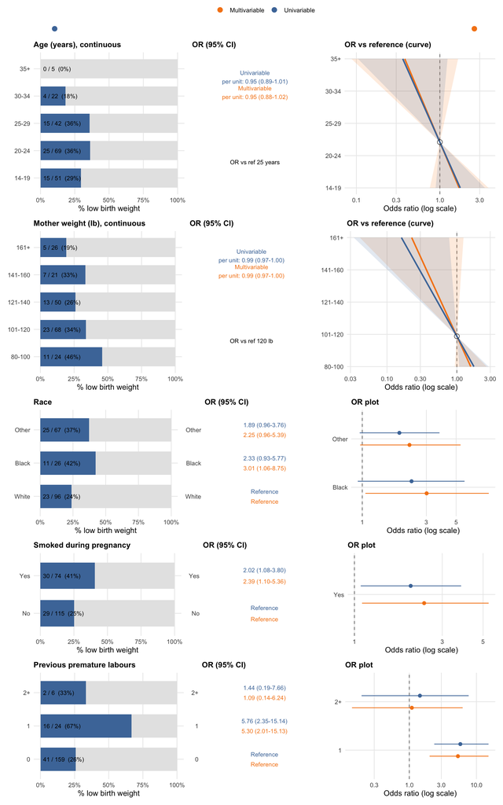

```r
age_levels <- levels(bwt$age_band)
lwt_levels <- levels(bwt$lwt_band)

strip_age <- make_continuous_strip(
  filter(raw_table, predictor == "Age (years), continuous"),
  age_uni_curve, age_multi_curve,
  "Age (years), continuous",
  uni_age, multi, "age", "years", age_ref, age_levels
)

strip_lwt <- make_continuous_strip(
  filter(raw_table, predictor == "Mother weight (lb), continuous"),
  lwt_uni_curve, lwt_multi_curve,
  "Mother weight (lb), continuous",
  uni_lwt, multi, "lwt", "lb", lwt_ref, lwt_levels
)

strip_race <- make_categorical_strip(
  filter(raw_table, predictor == "Race"),
  race_or, "Race", c("White", "Black", "Other")
)

strip_smoke <- make_categorical_strip(
  filter(raw_table, predictor == "Smoked during pregnancy"),
  smoke_or, "Smoked during pregnancy", c("No", "Yes")
)

strip_ptl <- make_categorical_strip(
  filter(raw_table, predictor == "Previous premature labours"),
  ptl_or, "Previous premature labours", c("0", "1", "2+")
)

legend_plot <- ggplot(tibble(model = c("Univariable", "Multivariable"), x = 1:2, y = 1),
                      aes(x, y, color = model)) +
  geom_point(size = 3) +
  scale_color_manual(values = c(Univariable = "#4C78A8", Multivariable = "#F58518")) +
  theme_void() +
  theme(legend.position = "top", legend.title = element_blank())

legend_plot / strip_age / strip_lwt / strip_race / strip_smoke / strip_ptl +
  plot_layout(heights = c(0.15, 1.2, 1.2, 0.9, 0.7, 0.9))
```

# Notes for adapting to the burns workshop

1. Keep raw % **binned** even when the model uses the continuous variable.
2. For continuous OR plots, pick a clinically meaningful reference (here age 25 and weight 120 lb; the screenshot example used age 35).
3. Always verify printed ORs against `tidy(model, conf.int = TRUE, exponentiate = TRUE)`.
4. Univariable and multivariable can share one figure by using two colors and dodged points / overlaid curves.
5. This layout is deliberately built from ggplot + patchwork so an LLM can modify strips without a specialized table package.